+++

## Why Uncertainty and Sensitivity?

## Why?

- We really don’t know
- Some of our guesses may be critical and senstivity analysis may guide us to spend more time supporting those assumptions.
- Clients may ask for risk assessments
- Clients may have other assumptions about critical parameters

## What do you mean “I don’t know”?

- We are way more certain than we should be.
- Example:
  - Make your best guess at the population of Keyna
  - Give yourself a reasonable upper and lower bound so you are 80% sure the true value is there.
  - Not zero to a billion
- 44.35 M.
  - One in five of you should be out of bounds.
  - Usually, if honest, more than one in five will be out.
  - If less, Hawthorn Effect

## Some parameters are more critical than others

- Cost effectivness depends on estimating costs and benefits.
- Example: Cost effectivness of an Energy Efficiency improvement
  - Costs, commonly install costs are easy to get.
  - Benefits, due to hours used, are critical.
- Low use, not cost effective.
- High use, cost effective.

## Client Requests

- It is not that they don’t trust you.
- Risk plays into setting a MARR.
  - High risk, high MARR
  - Low Risk, low MARR
- They want to know the probability of success
- It is part of a portfolio of risks:
  - They want to know how risky
  - They want to know how correlated it is with other risks.
- They like independent risks
- They like risks that are negativly correlated with existing risk

## Clients Have Different Assumptions

- They may disagree with you but you still want to show them that the results are valid
- There may be actual diversity.
  - Different costs at different locations.
  - Different experiences in differnt years.
- You need to do an analysis that covers all that.

## Warnings

## You Have Seen Sensitivity Analysis

- Recall the PW diagrams we used in learning IRR?
- Shows how PW changes with changes in MARR. $PW = +10 + \frac{15}{(1+r)}$

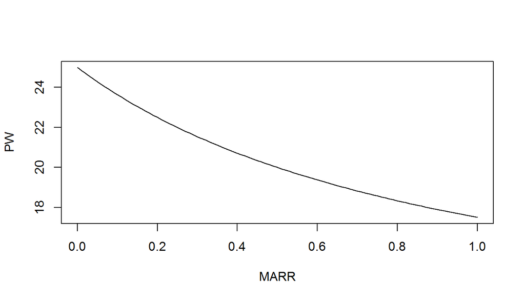

## Other Parameters

There are some parameters that are usually of concern:

- Initial costs
- Salvage value
- Scale

Some are harder than others:

- Planning horizon
- Uncertainty about Risks

## Why planning horizon is harder

- Mostly you assume time is discrete ++ not continuous.
- You need to either change to continuous discounting $\frac{1}{e^{N(1+r)}}$ rather than $\frac{1}{(1+r)^N}$
- Or create an equivelent MARR with smaller compounding periods but equivelent with their nominal statment.

## Example: MARR 10% per year compounded daily

Start with 10% per year MARR and find equivalent annual MARR compounded daily.

$$\left(1 + \frac{r}{365} \right)^{365} = 1.1$$

Allows you to vary time on a smaller time frame.

## Why uncertainty about risks is harder

- Risk is when you know the odds but don’t know the outcome.
  - You know that each side of a true die has a 1/6 chance of showing.
- Uncertainty is when you don’t know the odds.
  - Uncertain if it is your trick die that rolls a 6 half the time or the true die.
- You end up descibing your beliefs about the probability as a Beta distribution.
  - Hint, you just walked into the land of Bayesian statistics.
  - We will do some Monte Carlo simulations later so you can see what to do.
- Talk about your sensitivity analysis as about the mean of the present worth rather than the present worth.

## Simple How To

## PW Example

Consider a simple constant series that we can describe the present worth with factor notation:

$$P = C + A (P|A, i = r, N = n)$$

Lots of parameters to vary:

- A, the size of the constant benefits.
- r, the discount rate
- n, how long you get payments
- C, the initial cost

We warned you about r and n so lets vary just A

## PW Figure

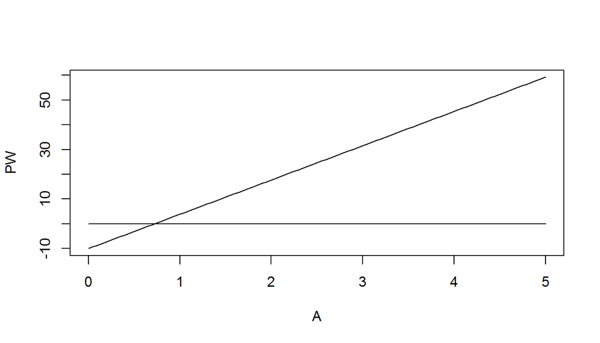

BTW PW is zero when A =0.7217385

## What Do You Learn from this?

- If you are pretty sure that A is not near 0.7217385, you are done spending time getting a better estimate of A.
  - Refining you estimate of the parameter with more data, more detailed calculations, more bids, more literature review will not change the decision.
  - Looking for more precision or less uncertainty is a waste of resource.
- If not, then you need to decide if the effort is worth the refinement. That depends on your other options.
  - Yes, sometimes you do a cost benefit analysis of doing cost benefit analysese.

## What Do You Learn from this? (Con’t)

- The client can check on the consequences of their beliefs about A.
- Note we still don’t know risk, for that we need to know the distribution of our beliefs about A.
  - Is it N(2, .5)?
  - Is it U(1,4)?
  - We will do this later.
- Sensitivity with present worth is easiest of the three.

## AW Example

- Stick with the same cash flow as before with present worth factor notation:

$$P = C + A (P|A, i = r, N = n)$$

- No more difficult than PW sensitivity analysis unless you want to vary the N.
- Annual worth is just

$$AW = A + C (A|P,i = r, N = n)$$

## AW Figure

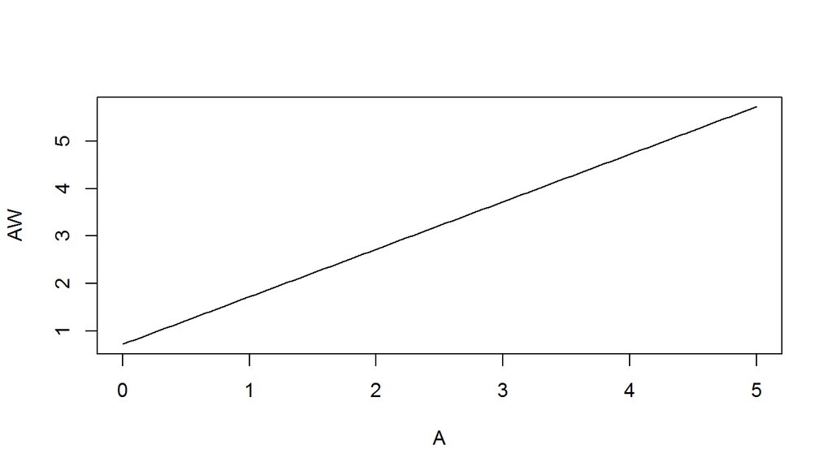

## Recall the PW function

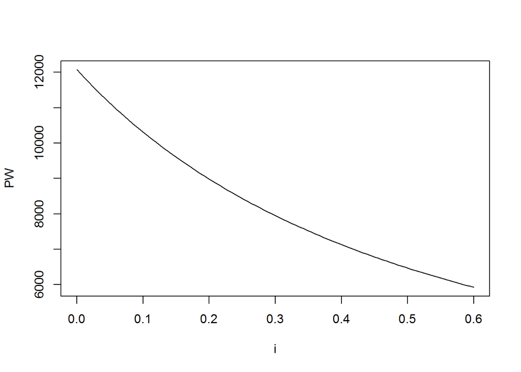

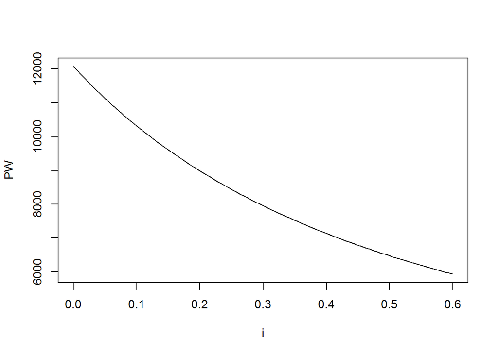

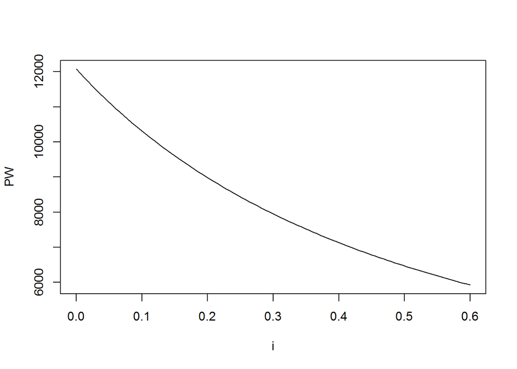

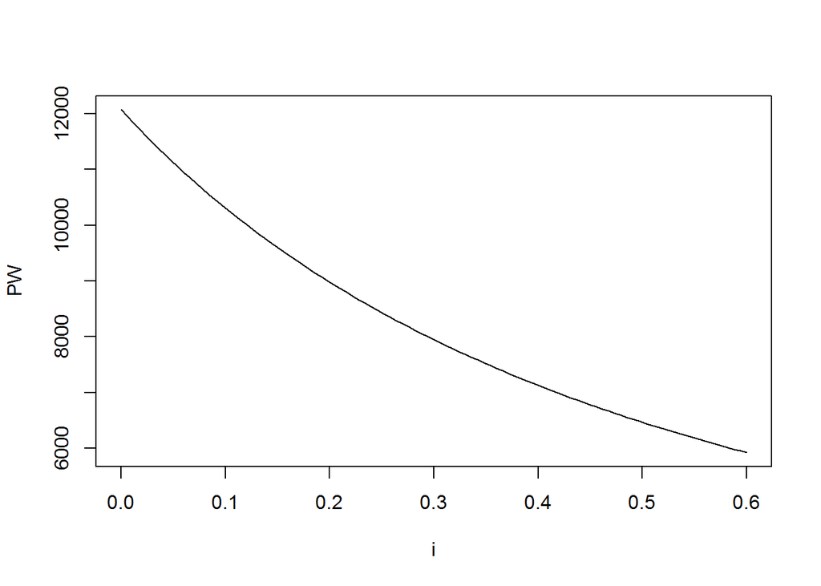

## IRR Problems

- Your IRR sensitivity functions are not always continuous.
- It requires a lot of time with clients to explain this.
- Recomend talking your clents out of it.

## Priors for Sensitivity Analysis

## Finding a Good Range

- In the examples above we just picked bounds.
- Book gives some bad advice on how to pick the design points, bounds, in a sensitivity analysis, $\pm$ 20%.
  - Sometimes 20% is way too big, remember the intial cost in the IRR example? 4$ on a scale of 1000$
  - Sometimes 20% is way too small. What is the smallest safety factor you have ever used? 1.25?

## Single Person

- A few warnings.
  - This does not work with everyone. They have to be reasonably numeric.
  - They have to be a real expert, with real opinions, real experience with data.
  - It is ok, if they need time, have to make some calculations or want to look a few things up.
- Three questions for each parameter
  - What is your best guess?
  - Largest value that you are 90% sure the value is below?
  - Smallest value that you are 90% sure the value is above?
  - Basically, what are your 80% bounds.

## Allows a Spider graph.

- Horizontal axis shows percent difference from best guess.
- Vertical shows the investment criteria of interest.

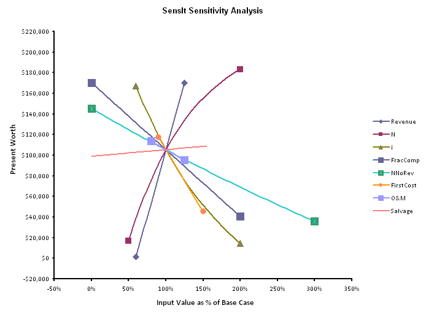

## What to watch for?

- Parameter that cause a decision, sign, change.
  - Can turn a good idea into a bad one without more research
- High sensitivity parameters, high slope.
  - Your expert may be more certain than they should be and should be consulted more about that parameter.
- Low sensitivity parameters, low slope.
  - No more time should be spent on these.
  - Unless, your job is devil’s advocate.

## Multi+Person

## Feasible

You have many choices:

- Ask everyone for their best guess for each parameter:
  - Leads to Monte Carlo Simulations.
  - Captures correlations between beliefs in parameters
- Delphi Survey:
  - Asks not just for numbers, but why you choose the number.
  - Monte Carlo Simulations

## Possible but difficult

- Ask everyone for the best guess and 80% bounds:
  - Beyond scope of course.
  - Use with small numbers of experts
  - Welcome again to Baysian land.
- Ask everyone for joint distributions:
  - Hard to to do.
  - Goes Bayesian again.
  - Never had a client that could do it.
  - I have trouble doing it.

## Example Joint Distributions

## Ask Everyone for best guess at each parameter.

- You need at least as many experts as parameters.
- If you have a lot of experts, 30+, you can simulate the objective function directly on the data or bootstrap for the uncertainty.
- If you have few, you can approximate with a multivariate normal distribution.

## What is Jamie’s BMI?

- Figure out Jamie’s Body Mass Index, $\frac{kg}{M^2}$.
- Collected these 10 guesses of height and weight in M and kg.

  | Ht | Wt |
  | --- | --- |
  | 2.139092 | 80.29541 |
  | 1.463353 | 83.90572 |
  | 1.605892 | 84.32471 |
  | 1.778271 | 84.87483 |
  | 1.898759 | 85.26588 |
  | 1.698715 | 86.80008 |
  | 2.135915 | 87.08079 |
  | 1.763164 | 86.37953 |
  | 1.690873 | 88.47560 |
  | 2.354199 | 88.01454 |

## Direct

- Experts say the median BMI is 27.3130004.
- 80% are sure it is between 17.3814079 and 33.3465223

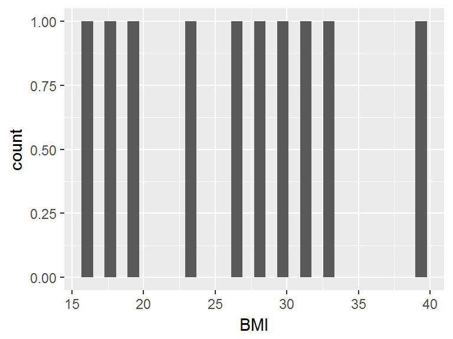

This is just plotting the data, which works with 30+ experts.

## Or Estimate the Joint Normal Distribution

- Means of 1.8528235, 85.5417097
- and var/cov of

| 0.0768683 | 0.0449123 |
| --- | --- |
| 0.0449123 | 5.7309822 |

## And Simulate for 1000 replications

- You can get exact results for Normals added to Normals but the minute you divide, stick to reporting confidence intervals, medians and modes.
- Normal divided by Normal is Cauchy, which has no defined mean and no defined variance.

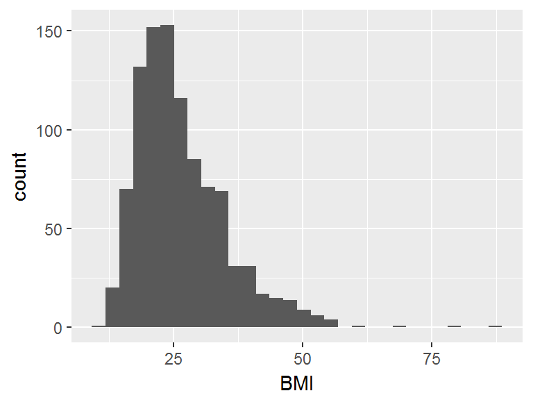

- 80% are sure the BMI is between 17.2982875 and 38.3251198

## Problems with “Just ask experts”

## Lack of structure causes problems

- Responses are not always independent
  - The boss is in the room and you don’t want to disagree.
  - Everyone uses the same reference document
  - Example, you can tell which field by the number people give for the value of a statistical life.
    - $9.1 million, Environmental Protection Agency
    - $7.9 million, Food and Drug Administration
    - $9.4 million, Transportation Department
- Little thought is put into it

## Fixes

- Use incentivized polls like Intel.
- Parimutuel betting, like some electrical utilities.
- Delphi Surveys

## Parimutuel Betting

- Guess Jamie’s BMI. Correct answers split the pot with the others that got it right.
- Racetrack method.
- Less likely to get bubbles, but
  - Harder to see if there is a mode in the guess.
- Cheaper than incentivized poll if high probability of multiple winners.
- Cost does not increase with a priori certainty.

## Delphi Surveys

General Pattern:

- Ask each person in private for best guess.
- Compile results.
- Ask outliers why they said what they did.
- Give everyone:
  - The distribution of guesses for each parameter
  - The reasons the outliers gave for the answer the gave.
- Ask for another guess.
- Report the new distribution or repeat if desired.

## Interested in More?